# GLMM Assignment

Brian D. Gerber

2024-8-22

### **Objective**

Create a report using Markdown that presents code, results, and summarized findings that makes inference to the occurence of the Annamite striped rabbit (*Nesolagus timminsi*) across multiple protected areas in Vietnam.

### **Background**

This is not real data. However, the basic premise has been adopted from the paper, [Getting the big picture: Landscape-scale occupancy patterns of two Annamite endemics among multiple protected areas](https://conbio.onlinelibrary.wiley.com/doi/full/10.1111/csp2.620).

### **Overview**

The Annamite striped rabbit is a forest-dwelling lagomorph that was discovered by science in the mid-1990s. Little is known about this species. What has been done indicates that hunting pressure is a primary driver of its distribution. As such, protected areas are paramount to their conservation. However, protected areas vary in their effectiveness in limiting hunting and some protected areas are founded on multi-use, such that hunting is still allowed.

[figure not shown]

### Data and Hypothesis

Working with your colleagues, they outline their hypothesis that the main driver of rabbit occurrence is hunting within the protected areas. However, there is no spatial variable or direct measure of hunting pressure throughout the park. Rather, they predict that increasing distance away from human activity will lead to higher rabbit occupancy because people will only travel so far in difficult mountainous terrain. They also hypothesize that this effect will vary by protected area because there is different levels of patrolling and enforcement. But, regardless of protected area, they hypothesize that occurrence at the edge of the protected areas nearest to human activity will be the same because of the similar density of people and that occurrence will be very low.

#### *To do*

Fit the data (`rabbit.occ.data.csv`) using a single model that captures the hypothesis of your colleague.

- visualize and summarize the data
- present all parameters with measures of uncertainty
- describe what each parameter means; discuss relevant measures of statistical clarity using hypothesis tests or confidence intervals
- make sure to provide evidence whether there is or is not variation of ‘dist.human’ across protected areas
- make prediction plots that display all relevant variables: `PA` and `dist.human`
- make a prediction plot for a ‘typical’ protected area; make it clear why this results is important
- summarize results and offer suggestions for the type of followup study that would be useful

### *Visualize the Data*

```r
library(ggplot2)
dat = read.csv("rabbit.occ.data.csv")

# data structure and attributes
  str(dat)
```

```
## 'data.frame':    250 obs. of  5 variables:
##  $ X         : int  1 2 3 4 5 6 7 8 9 10 ...
##  $ PA        : chr  "PA1" "PA1" "PA1" "PA1" ...
##  $ camera    : int  1 2 3 4 5 6 7 8 9 10 ...
##  $ occur     : int  0 0 0 0 0 0 0 0 0 1 ...
##  $ dist.human: num  140 188 363 408 504 ...
```

```r
# frequency of 0's and 1's
  table(dat$occur)
```

```
##
##   0   1
## 107 143
```

```r
# how many cameras at each protected area
  table(dat$PA)
```

```
##
## PA1 PA2 PA3 PA4 PA5
##  50  50  50  50  50
```

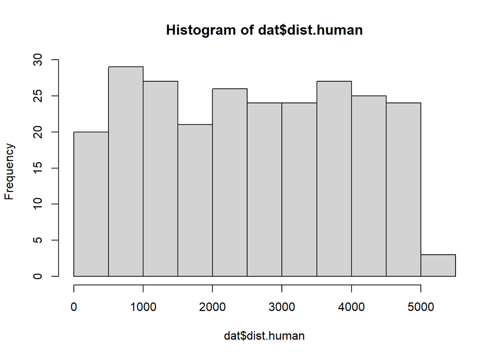

```r
# histogram of distance to human activity
  hist(dat$dist.human)
```

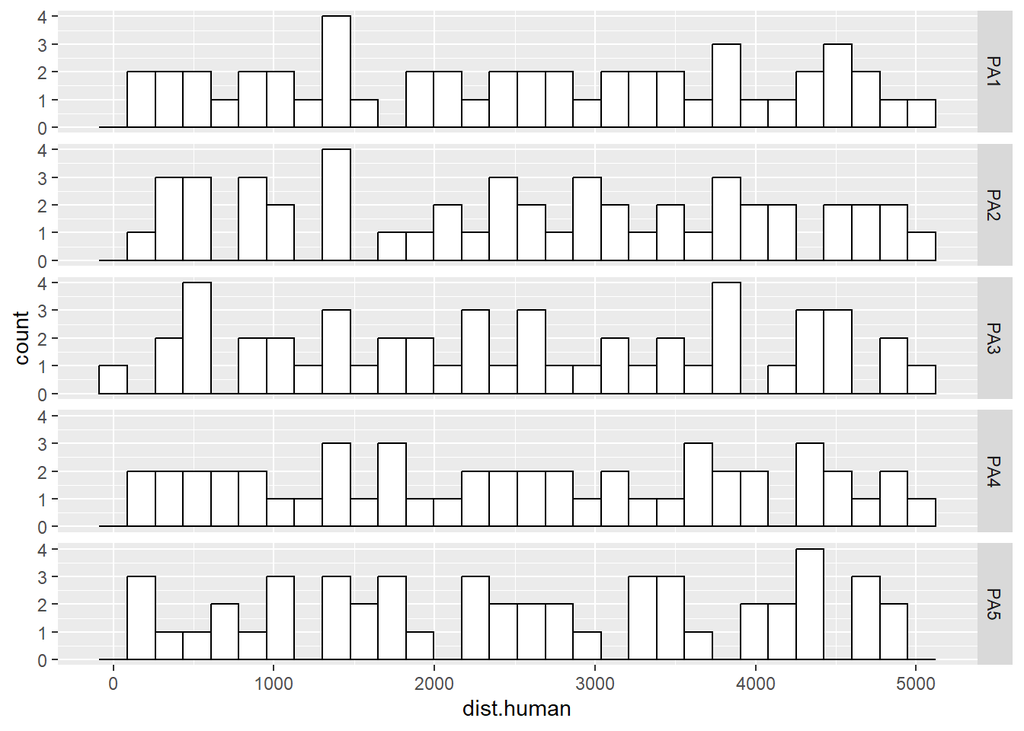

```r
# histograms of human activity measured across PA's
ggplot(dat, aes(x=dist.human))+
  geom_histogram(color="black", fill="white")+
  facet_grid(PA ~ .)
```

### *Model Fitting*

To evaluate the hypothesis, I fit a hierarchical binomial regression model to the rabbit occurrence data. First, to improve model convergence and maintain the main covariate of interest in terms of an understandable measure of distance, I scaled the `dist.human` variable by 1000 to obtain distance in kilometers. This also allows the intercept to reflect the logit-value of occurence when `dist.human` is zero, which is a consideration of the hypothesis.

The model includes a fixed effect intercept (i.e., does not very by protected area) and a random effect for scaled distance to human activity (`dist.human.sc`) by protected area (i.e., the slope does vary by protected area). This model structure captures the types of variation proposed in the hypothesis. I will use $\alpha = 0.05$ to determine statistical clarity.

```r
library(glmmTMB)

#scale distances to kilometers
dat$dist.human.sc = dat$dist.human/1000

model = glmmTMB(occur~dist.human.sc+(0+dist.human.sc||PA),
                family=binomial(link="logit"),
                data=dat
                )
```

### *Results*

```r
summary(model)
```

```
##  Family: binomial  ( logit )
## Formula:          occur ~ dist.human.sc + (0 + dist.human.sc || PA)
## Data: dat
##
##      AIC      BIC   logLik deviance df.resid
##    268.5    279.1   -131.3    262.5      247
##
## Random effects:
##
## Conditional model:
##  Groups Name          Variance Std.Dev.
##  PA     dist.human.sc 0.1118   0.3343
## Number of obs: 250, groups:  PA, 5
##
## Conditional model:
##               Estimate Std. Error z value Pr(>|z|)
## (Intercept)    -1.9236     0.3310  -5.811 6.21e-09 ***
## dist.human.sc   0.9798     0.2057   4.764 1.90e-06 ***
## ---
## Signif. codes:  0 '***' 0.001 '**' 0.01 '*' 0.05 '.' 0.1 ' ' 1
```

```r
confint(model)
```

```
##                               2.5 %     97.5 %   Estimate
## (Intercept)              -2.5723889 -1.2747725 -1.9235807
## dist.human.sc             0.5766640  1.3829012  0.9797826
## Std.Dev.dist.human.sc|PA  0.1377511  0.8115265  0.3343481
```

In our summary outputs, we see that the population mean (across protected areas) slope is statistically clearly different than zero (p-value is < $\alpha$ and 95% confidence intervals do not include zero) and is positive. As such, across all protected areas (including unsampled areas), a ‘typical’ protected area is expected to have increasing occurrence of the striped rabbit the further from centers of human activity. The prediction that striped rabbit occurrence would be low near human activity is supported with a predicted occurrence of 0.13 (i.e., plogis(-1.9236)) at a distance of zero. We also see that there is support for variation in the effect of `dist.human.sc` as the standard deviation of the protected area slope differences is well above zero at 0.33 and the 95% confidence intervals do not include zero.

```r
broom.mixed::tidy(model, effects = "ran_vals", conf.int = TRUE)
```

```
## # A tibble: 5 × 9
##   effect   component group level term      estimate std.error conf.low conf.high
##   <chr>    <chr>     <chr> <chr> <chr>        <dbl>     <dbl>    <dbl>     <dbl>
## 1 ran_vals cond      PA    PA1   dist.hum…  -0.192      0.188  -0.561     0.177
## 2 ran_vals cond      PA    PA2   dist.hum…   0.0409     0.191  -0.334     0.416
## 3 ran_vals cond      PA    PA3   dist.hum…  -0.349      0.189  -0.720     0.0211
## 4 ran_vals cond      PA    PA4   dist.hum…   0.533      0.264   0.0159    1.05
## 5 ran_vals cond      PA    PA5   dist.hum…  -0.0941     0.189  -0.465     0.277
```

Looking at the protected area specific differences from the population-mean (i.e., the random effect values), we see the largest difference of 0.53 for protected area 4, which is statistically clearly different than zero as the 95% confidence intervals do not include 0. No other random effect are statistically clearly different than the population mean. This suggests an increase in power is warranted by sampling more sites at each protected area.

If we combine the population mean effect and the differences by protected area, we get the mean slope of `dist.human.sc` by protected area. We see that all slopes are positive, indicating that there is no evidence that increasing distances reduces rabbit occurence.

```r
fixef(model)[[1]][2]+ranef(model)[[1]]$PA
```

```
##     dist.human.sc
## PA1     0.7876961
## PA2     1.0206335
## PA3     0.6305017
## PA4     1.5128966
## PA5     0.8857225
```

Next, lets visualize the probability of rabbit occurrence at a typical site. This is an important result, as it captures the relationship we would expect at protected areas we have not sampled.

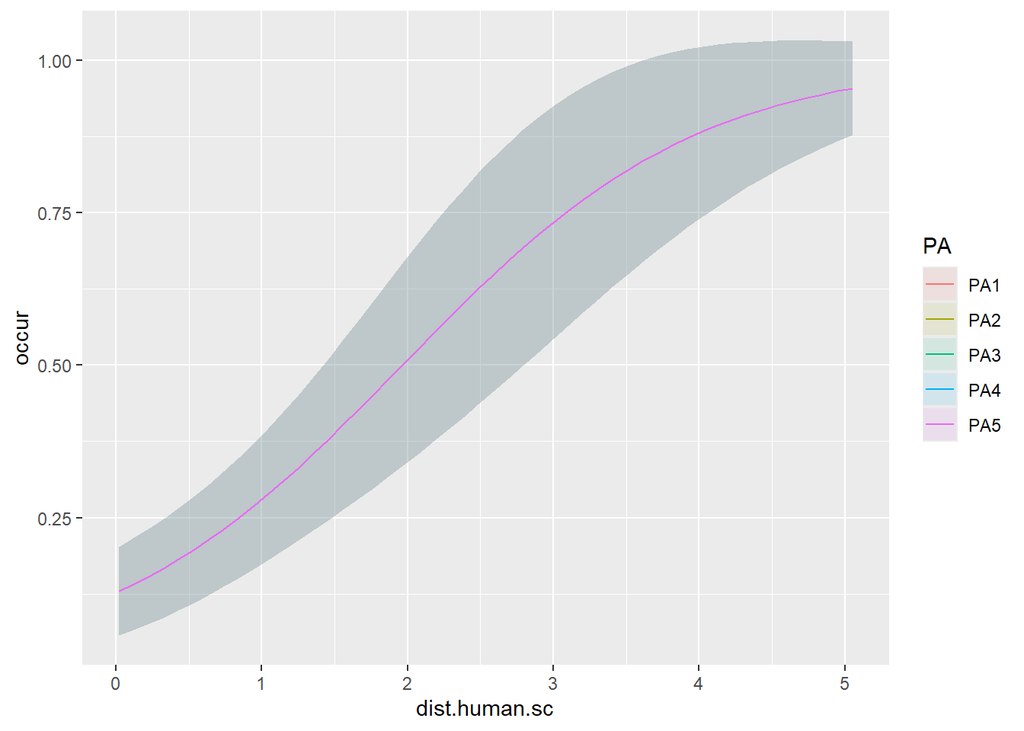

```r
marginaleffects::plot_predictions(model,
                                  condition=c("dist.human.sc","PA"),
                                  type="response",
                                  re.form=NA,
                                  vcov=TRUE
)
```

Next, we see that there is clear variation of the effect of `dist.human.sc` by protected area and that none of the slopes are negative.

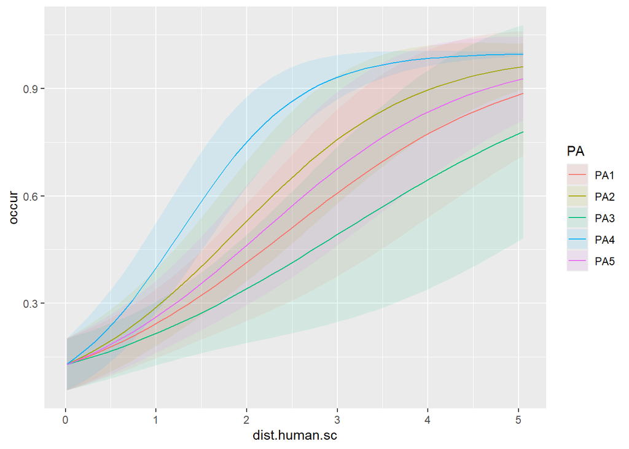

```r
marginaleffects::plot_predictions(model,
                                  condition=c("dist.human.sc","PA"),
                                  type="response",
                                  re.form=NULL,
                                  vcov=TRUE
)
```

### *Conclusion*

We found support for our hypothesis. There is evidence for variation of the effect of distance to human activity on striped rabbit occurence and that as distances increases, occurrence increases. We are measuring a proxy for hunting pressure, but assuming distance relates to human hunting pressure and not other confounding factors, our hypothesis is supported. A follow up study might want to plan for increasing the sampling at each protected area to better test for differences of the main effect by protected area (i.e., increase the statistical power). Second, we may want to consider a random intercept to evaluate the hypothesis that there is variation of rabbit occurrence near human activity.